# UNIT06C：機率的策略應用案例

中山大學管理學院 卓雍然

2019-10-14 21:17:59

```r
pacman::p_load(dplyr, vcd)
```

### 【A】實務案例一：擲筊的成功機率

🧙 問題討論：  
在`cup.csv`檔案裡面是一千個信徒的擲筊次數，假定每一個人都是擲到3次成功才停止，請問：  
■ 這些擲筊次數是甚麼分佈？ 它的參數是？  
■ 這個筊的成功機率大約是？  
■ 請畫出用這個筊擲10次成功之前，失敗次數的機率分布？  
■ 用這個筊擲15次還不能有5次成功的機率是？

失敗次數是Poisson嗎？ (因為擲到3次成功才停止，所以失敗次數等於擲筊次數減三)

```r
X = read.csv("cup.csv")$x
fit =  goodfit(table(X - 3), "poisson")
summary(fit)
```

```
     Goodness-of-fit test for poisson distribution

                    X^2 df    P(> X^2)
Likelihood Ratio 1605.4 33 5.0416e-317
```

已知成功次數為3，用Negative Binomial試試看

```r
fit =  goodfit(table(X - 3), "nbinom", par=list(size=3))
summary(fit)
```

```
     Goodness-of-fit test for nbinomial distribution

                    X^2 df P(> X^2)
Likelihood Ratio 37.564 33  0.26795
```

```r
fit$par
```

```
$size
[1] 3

$prob
[1] 0.248
```

🗿 : 這個筊的成功機率大約是？

```r
#
```

🗿 : NBinomial[n=3,p=0.248]是 … 的分佈？

```r
#
```

🗿 : 畫出用這個筊擲10次成功之前，失敗次數的機率分布

```r
#
```

🗿 : 用這個筊擲15次還不能有5次成功的機率是？

```r
#
```

### 【B】實務案例二：老忠實賭局

🗿 問題討論：  
假如賭場老闆從零開始把每10秒鐘設為一個區間，每個區間的賭金是五塊錢 …  
■ 你要怎麼押注，才能獲得最高的期望報酬呢？  
■ 你的賭金和期望報酬各是多少？  
將獲利的期望報酬和賭金的比值稱為「期望投資報酬率」 …  
■ 「最大期望投資報酬率」的策略是？  
■ 這個策略的期望報酬和報酬率各是多少？  
■ 它和最高期望報酬的策略是相同的嗎？  
■ 哪一個策略目標比較好呢？  
■ 我們應該如何選擇(設定)策略目標呢？

§ 使用R的內建的功能建立PDF模型

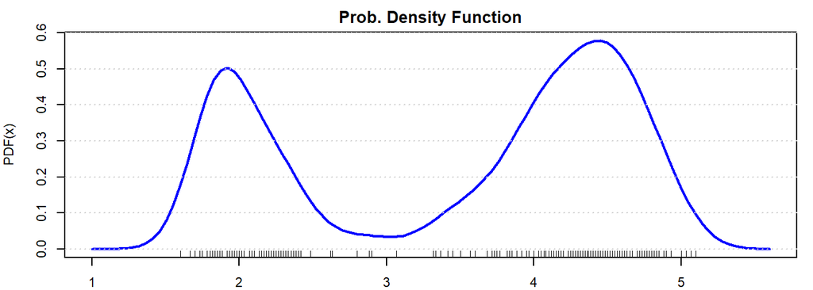

```r
D = faithful$eruptions        # copy data to a short name
Adjust = 0.5                       # bandwidth adjustment
DEN = density(D, adjust = Adjust)      # density function
PDF = approxfun(DEN$x, DEN$y, yleft=0, yright=0)    # PDF

par(mar=c(2,4,2,1), cex=0.7)
curve(PDF(x), 1, 5.6, col='blue',lwd=2,main="Prob. Density Function")
rug(D)
abline(h=seq(0,1,0.1),col='lightgrey',lty=3)
```

§ 利用模型策略規劃

```r
x1 = seq(1, 6, 1/6); x2 = x1 + (1/6)     # 臨界值
px = sapply(1:length(x1), function(i) {  # 機率
  integrate(PDF, x1[i], x2[i])$value     #
  })
net = 100 * px - 5                       # 淨期望報酬
data.frame(x1, x2, px, net) %>%
  arrange(desc(net)) %>%
  mutate(
    payoff =  cumsum(net),               # 累計(淨)期望報酬
    investment = row_number() * 5,       # 累計投資、資本需求
    roi = payoff / investment            # 累計投報率
    ) %>% filter(net > 0) %>% round(3)
```

```
     x1    x2    px   net payoff investment   roi
1 4.333 4.500 0.096 4.577  4.577          5 0.915
2 4.500 4.667 0.089 3.938  8.515         10 0.852
3 4.167 4.333 0.089 3.932 12.447         15 0.830
4 1.833 2.000 0.082 3.226 15.673         20 0.784
5 4.000 4.167 0.077 2.654 18.327         25 0.733
6 2.000 2.167 0.070 1.968 20.294         30 0.676
7 4.667 4.833 0.068 1.843 22.137         35 0.632
8 1.667 1.833 0.064 1.367 23.504         40 0.588
9 3.833 4.000 0.058 0.834 24.338         45 0.541
```

🗿 問題討論：  
將獲利的期望報酬和賭金的比值稱為「期望投資報酬率」 …  
■ 「最大期望投資報酬率」的策略是？  
■ 這個策略的期望報酬和報酬率各是多少？  
■ 它和最高期望報酬的策略是相同的嗎？  
■ 哪一個策略目標比較好呢？  
■ 我們應該如何選擇(設定)策略目標呢？

💡 學習重點：  
■ 如何求出機率分布函數？  
A. 將實證資料`fit`進已知的理論分布、並求出參數  
B. 直接就實證資料做成(平滑)機率密度函數  
■ 即使是很簡單的一個案例，我們也需要綜合使用機率、程式和商業知識，才能做出合適的決策！  
■ 機率分布的商業應用套路：  
1. 寫出各事件(變數區間)的報償  
2. 求出變數的機率分布函數  
3. 求出各事件的機率  
4. 求出不同策略的期望報償  
5. 依公司的策略目標做選擇